# Data Analytics & Visualization

DA5020 / Practicum I

Mitchell Whelan

Spring 2025

# Part A

```r
# Load data from the TSV file using url
financeDF <- read.table("https://s3.us-east-2.amazonaws.com/artificium.us/datasets/pharma-sales-randomized.tsv", header = TRUE, stringsAsFactors = FALSE,
                        sep = '\t')
```

```r
suppressPackageStartupMessages(library(kableExtra))
suppressPackageStartupMessages(library(dplyr))
suppressPackageStartupMessages(library(lubridate))
```

# Part B

```r
# iterate through all rows and clean revenue/expenses columns
for (i in 1:nrow(financeDF)) {
  financeDF$revenue[i] <- sub("\\$", "", financeDF$revenue[i])
  financeDF$expenses[i] <- sub("\\$", "", financeDF$expenses[i])
}
# make both columns numeric for analysis
financeDF$revenue <- as.numeric(financeDF$revenue)
financeDF$expenses <- as.numeric(financeDF$expenses)
```

## I and II

```r
## find outliers and missing values in revenue column and replace them with the mean
mean.rev <- mean(financeDF$revenue, na.rm=TRUE)
med.rev <- median(financeDF$revenue, na.rm=TRUE)
sd.rev <- sd(financeDF$revenue, na.rm=TRUE)

z.rev <- abs((financeDF$revenue - mean.rev) /  sd.rev)

for (i in 1:length(z.rev)) {
  if (is.na(z.rev[i])) {
    financeDF$revenue[i] <- med.rev
  }
  else if (z.rev[i] > 2.5) {
    financeDF$revenue[i] <- med.rev
  }
}

## find outliers and missing values in expenses column and replace them with the mean
mean.exp <- mean(financeDF$expenses, na.rm=TRUE)
med.exp <- median(financeDF$expenses, na.rm=TRUE)
sd.exp <- sd(financeDF$expenses, na.rm=TRUE)

z.exp <- abs((financeDF$expenses - mean.exp) /  sd.exp)

for (i in 1:length(z.exp)) {
  if (is.na(z.exp[i])) {
    financeDF$expenses[i] <- med.exp
  }
  else if (z.exp[i] > 2.5) {
    financeDF$expenses[i] <- med.exp
  }
}
```

### Explanation:

The above code identifies missing values by checking if the calculated z-score is an NA value and checks for outliers by checking if the data point is more than 2.5 standard deviations away from the mean. I chose to replace these outliers/missing values by the median of the corresponding column. I chose to replace the values rather than delete the entire row because we are dealing with month-by-month data and I feel that having random gaps in our data due to outliers/missing values will detract from our analysis. Furthermore, I chose to use the median of the column as a placeholder instead of the mean because the mean is much more susceptible to being impacted by outliers. The expenses column of this dataset is the perfect example. The mean was about 47 due to the one outlier, even though no other entries in that column are close to 47. The median is a great alternative as a placeholder that is less susceptible to outliers.

## III

```r
# changes date column to a DATE object and parses month, day, and year from that object
financeDF$date <- mdy(financeDF$date)
financeDF$month <- month(financeDF$date)
financeDF$day <- day(financeDF$date)
financeDF$year <- year(financeDF$date)
```

## IV

```r
# creates Profit/Loss column
financeDF$ProfitLoss <- (financeDF$revenue - financeDF$expenses) * 1000
```

# Part C

## Table 1

```r
# creates quarter column
financeDF$quarter <- quarter(financeDF$date)

# creates table using kable
quarterly_revenue <- financeDF %>%
  group_by(year, quarter) %>%
  summarise(total_revenue = sum(revenue))
quarterly_revenue_table <- quarterly_revenue %>%
  kable("html", caption = "Quarterly Revenue per Year", col.names = c("Year", "Quarter", "Total Revenue")) %>%
  kable_styling("striped", full_width = T)

print(quarterly_revenue_table)
```

Quarterly Revenue per Year

| Year | Quarter | Total Revenue |
| --- | --- | --- |
| 2022 | 1 | 81.04 |
| 2022 | 2 | 78.81 |
| 2022 | 3 | 86.98 |
| 2022 | 4 | 91.14 |
| 2023 | 1 | 80.09 |
| 2023 | 2 | 77.30 |
| 2023 | 3 | 81.92 |
| 2023 | 4 | 84.12 |
| 2024 | 1 | 72.37 |
| 2024 | 2 | 79.34 |
| 2024 | 3 | 77.98 |
| 2024 | 4 | 76.77 |

## Table 2

```r
# creates table using kable
monthly_avg <- financeDF %>%
  group_by(month) %>%
  summarise(
    avg_profit_loss = round(mean(ProfitLoss), 2)
  )

monthly_avg_table <- monthly_avg %>%
  kable("html", caption = "Monthly Average Profit/Loss Across Years", col.names = c("Month","Average Profit/Loss")) %>%
  kable_styling("striped", full_width = T)

print(monthly_avg_table)
```

Monthly Average Profit/Loss Across Years

| Month | Average Profit/Loss |
| --- | --- |
| 1 | 3613.33 |
| 2 | 3266.67 |
| 3 | 2293.33 |
| 4 | 2080.00 |
| 5 | 2320.00 |
| 6 | 3403.33 |
| 7 | 4206.67 |
| 8 | 3973.33 |
| 9 | 4110.00 |
| 10 | 5203.33 |
| 11 | 5450.00 |
| 12 | 6183.33 |

## Table 3

```r
# arranges columns chronologically and then calculates percentage change using lag
monthlyChangeTable <- financeDF %>%
  arrange(year, month) %>%
  mutate(
    revenueChange = round((revenue - lag(revenue)) / lag(revenue) * 100, 2),
    expensesChange = round((expenses - lag(expenses)) / lag(expenses) * 100, 2),
    profitLossChange = round((ProfitLoss - lag(ProfitLoss)) / lag(ProfitLoss) * 100, 2)) %>%
  select(year, month, revenueChange, expensesChange, profitLossChange
  )

# Create the table with kable
monthlyChangeTableKable <- monthlyChangeTable %>%
  kable("html", caption = "Percentage Change in Revenue, Expenses, and Profit/Loss from Previous Month", col.names = c("Year", "Month", "Revenue Change (%)", "Expenses Change (%)", "Profit/Loss Change (%)")) %>%
  kable_styling("striped", full_width = T)

print(monthlyChangeTableKable)
```

Percentage Change in Revenue, Expenses, and Profit/Loss from Previous Month

| Year | Month | Revenue Change (%) | Expenses Change (%) | Profit/Loss Change (%) |
| --- | --- | --- | --- | --- |
| 2022 | 1 | NA | NA | NA |
| 2022 | 2 | -3.86 | -1.75 | -13.99 |
| 2022 | 3 | -5.42 | 0.26 | -36.60 |
| 2022 | 4 | -1.75 | 2.13 | -35.47 |
| 2022 | 5 | 3.81 | 1.06 | 41.52 |
| 2022 | 6 | 4.70 | -2.86 | 78.93 |
| 2022 | 7 | 4.78 | 1.13 | 24.25 |
| 2022 | 8 | -1.25 | -2.10 | 2.42 |
| 2022 | 9 | 5.43 | -2.71 | 39.20 |
| 2022 | 10 | -0.03 | -1.35 | 3.78 |
| 2022 | 11 | 3.08 | -3.92 | 22.36 |
| 2022 | 12 | -1.20 | -1.66 | -0.21 |
| 2023 | 1 | -11.43 | 6.52 | -49.69 |
| 2023 | 2 | 1.11 | 1.86 | -2.25 |
| 2023 | 3 | -5.10 | -0.31 | -27.62 |
| 2023 | 4 | 0.62 | 5.53 | -31.21 |
| 2023 | 5 | -2.92 | 2.54 | -57.14 |
| 2023 | 6 | 2.89 | -0.12 | 74.51 |
| 2023 | 7 | 2.81 | -0.50 | 47.75 |
| 2023 | 8 | -0.07 | 3.40 | -31.94 |
| 2023 | 9 | 6.63 | 4.94 | 30.17 |
| 2023 | 10 | -0.32 | -11.74 | 127.90 |
| 2023 | 11 | -2.75 | 4.90 | -35.97 |
| 2023 | 12 | 1.85 | -2.19 | 30.59 |
| 2024 | 1 | -16.43 | -5.36 | -75.45 |
| 2024 | 2 | 2.72 | 3.97 | -22.94 |
| 2024 | 3 | 2.44 | 2.83 | -8.33 |
| 2024 | 4 | 2.02 | -3.67 | 179.22 |
| 2024 | 5 | 5.98 | 0.61 | 63.72 |
| 2024 | 6 | 2.36 | 0.22 | 16.48 |
| 2024 | 7 | -3.80 | -6.66 | 12.44 |
| 2024 | 8 | -0.23 | -0.32 | 0.22 |
| 2024 | 9 | -3.39 | 6.47 | -49.57 |
| 2024 | 10 | 0.04 | 0.00 | 0.43 |
| 2024 | 11 | 0.98 | -2.69 | 37.18 |
| 2024 | 12 | 0.39 | -4.81 | 36.76 |

# Part D

```r
# arrance the dataframe by year and month so that the most recent data entry is at the bottom row of the dataframe
financeDF <- financeDF %>%
  arrange(year, month)

#calculate the prediction using the bottom row of financeDF
predictionRow <- data.frame(
  date = financeDF$date[nrow(financeDF)] + months(1),
  revenue = .6*financeDF$revenue[nrow(financeDF)] + .3*financeDF$revenue[nrow(financeDF) - 1] + .1*financeDF$revenue[nrow(financeDF) - 2],
  expenses = .6*financeDF$expenses[nrow(financeDF)] + .3*financeDF$expenses[nrow(financeDF) - 1] + .1*financeDF$expenses[nrow(financeDF) - 2])

predictionRow$month = month(predictionRow$date)
predictionRow$day = 1
predictionRow$year = year(predictionRow$date)
predictionRow$ProfitLoss = (predictionRow$revenue - predictionRow$expenses) * 1000
predictionRow$quarter = quarter(predictionRow$date)

print(predictionRow)
```

| date | revenue | expenses | month | day | year | ProfitLoss | quarter |
| --- | --- | --- | --- | --- | --- | --- | --- |
| 2025-01-01 | 25.675 | 21.844 | 1 | 1 | 2025 | 3831 | 1 |

# Part E

```r
#function that adds a new row to the given financeDF with appropriate data
addPredRow <- function(df) {
  newRow <- data.frame(
  date = df$date[nrow(df)] + months(1),
  revenue = .6*df$revenue[nrow(df)] + .3*df$revenue[nrow(df) - 1] + .1*df$revenue[nrow(df) - 2],
  expenses = .6*df$expenses[nrow(df)] + .3*df$expenses[nrow(df) - 1] + .1*df$expenses[nrow(df) - 2])

  newRow$month = month(newRow$date)
  newRow$day = 1
  newRow$year = year(newRow$date)
  newRow$ProfitLoss = (newRow$revenue - newRow$expenses) * 1000
  newRow$quarter = quarter(newRow$date)

  newDF <- rbind(df, newRow)
  return(newDF)
}
```

```r
#arrange the dataframe chronologically
visualDF <- financeDF %>%
  arrange(year, month)

# need to add a new row twice for plotting the predicted profit/loss
visualDF <- addPredRow(visualDF)
visualDF <- addPredRow(visualDF)

# needed for scale
visualDF$ProfitLoss <- visualDF$ProfitLoss / 1000

#can't calculate prediction for these points so give placeholders
visualDF$predProfitLoss[1] <- 0
visualDF$predProfitLoss[2] <- 0
visualDF$predProfitLoss[3] <- 0

# calculate the predicted profit/loss for each row after 3
for (i in 1:nrow(visualDF)) {
  if (i > 3) {
    visualDF$predProfitLoss[i] <- .6*visualDF$revenue[i-1] + .3*visualDF$revenue[i-2] + .1*visualDF$revenue[i-3] - (.6*visualDF$expenses[i-1] + .3*visualDF$expenses[i-2] + .1*visualDF$expenses[i-3])
  }
}
```

```r
# Plot the first line and set up axis
plot(visualDF[1:(nrow(visualDF) - 2), ]$date, visualDF[1:(nrow(visualDF) - 2), ]$ProfitLoss, type = "l", frame = FALSE, pch = 19,
     main = "Profit & Loss By Month",
     sub = "Trend Over Time",
     col = "blue", xlab = "Date (Monthly)", ylab = "Amount (Thousands of $)", xaxt = "n", lwd = 2)

# set up indices for labels
indices <- seq(1, nrow(visualDF), by = 12)

# Plot the second line
lines(visualDF[4:nrow(visualDF), ]$date, visualDF[4:nrow(visualDF), ]$predProfitLoss, pch = 19, col = "red", type = "l", lwd = 2)
```

```r
# add labels every 12 months
axis(1, at = visualDF[indices, ]$date, labels = format(visualDF[indices, ]$date, "%b %y"))

# add the legend
legend("topright", legend=c("Actual Profit/Loss", "Predicted Profit/Loss"),
       col=c("blue", "red"), lty = 1:1, cex=1)
```

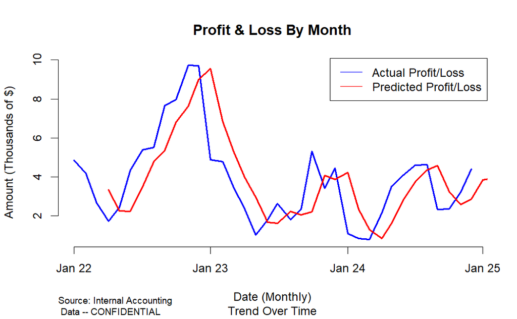

```r
#manually add source
mtext("Source: Internal Accounting \n Data -- CONFIDENTIAL", side = 1, line = 4, cex = 0.8, adj = 0, col = "black")
```